# An example of an fMRI analysis in FSL

## 6.1 Let’s Make a Matrix!

`img_ts_to_matrix` creates $V\times T$ matrix, $V$ voxels in mask, unlike `ANTsR::timeseries2matrix`. Therefore, we transpose the matrix so that it is consistent with the ANTsR tutorial for fMRI and so `boldMatrix` is $T\times V$. We will get the average of the co-registered image using `fslmaths`. We wil use this average image to get a mask using the `oMask` function, which calls `getMask`, but for `nifti` objects. We will then zero out the average image using the mask image.

```r
moco_avg_img = fslmaths(moco_fname, opts = "-Tmean")
```

```
fslmaths "/Users/johnmuschelli/Dropbox/Projects/neuroc/fmri_analysis_fslr/113-01-fMRI_motion_corr.nii.gz"  -Tmean "/var/folders/1s/wrtqcpxn685_zk570bnx9_rr0000gr/T//RtmpZOrA0i/file16f323480d370";
```

```r
maskImage = oMask(moco_avg_img,
    mean(moco_avg_img),
    Inf, cleanup = 2)
mask_fname = paste0(base_fname, "_mask.nii.gz")
writenii(maskImage, filename = mask_fname)

bet_mask = fslbet(moco_avg_img) > 0
```

```
bet2 "/private/var/folders/1s/wrtqcpxn685_zk570bnx9_rr0000gr/T/RtmpZOrA0i/file16f321d509357.nii.gz" "/var/folders/1s/wrtqcpxn685_zk570bnx9_rr0000gr/T//RtmpZOrA0i/file16f325bfe6f98"
```

```r
bet_mask_fname = paste0(base_fname, "_bet_mask.nii.gz")
writenii(bet_mask, filename = bet_mask_fname)
```

We can also look at the differences. We will assume the `maskImage` as the “gold standard” and `bet_mask` to be the “prediction”.

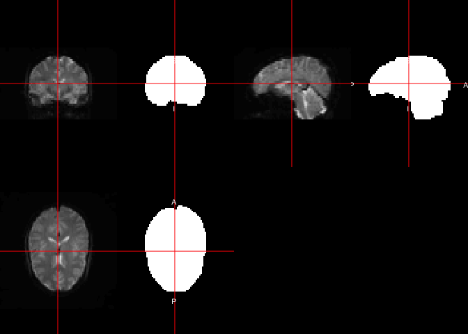

```r
double_ortho(moco_avg_img, maskImage,
  col.y = "white")
```

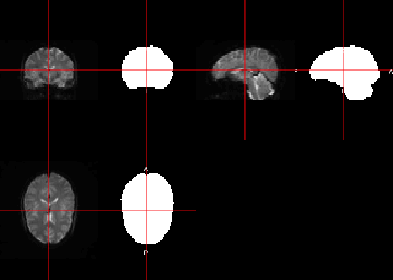

```r
double_ortho(moco_avg_img, bet_mask,
  col.y = "white")
```

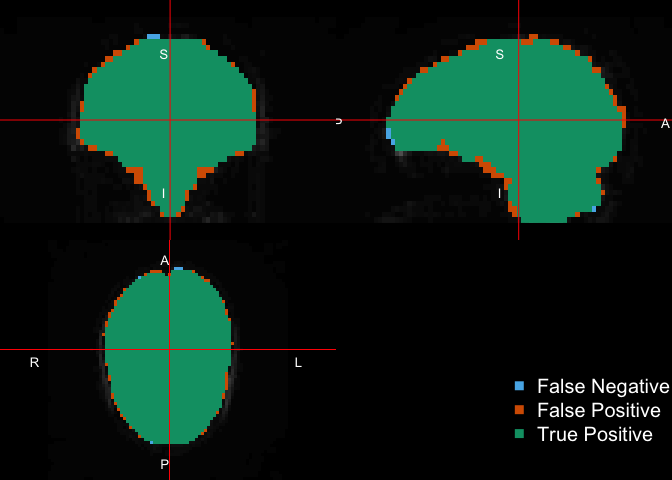

```r
ortho_diff( moco_avg_img, roi = maskImage, pred = bet_mask )
```

Here we will create a matrix of time by voxels.

```r
moco_avg_img[maskImage == 0] = 0
boldMatrix = img_ts_to_matrix(
    moco_img)
boldMatrix = t(boldMatrix)
boldMatrix = boldMatrix[ , maskImage == 1]
```

### 6.1.1 Calculation of DVARS

```r
dvars = ANTsR::computeDVARS(boldMatrix)
dMatrix = apply(boldMatrix, 2, diff)
dMatrix = rbind(rep(0, ncol(dMatrix)), dMatrix)
my_dvars = sqrt(rowMeans(dMatrix^2))
head(cbind(dvars = dvars, my_dvars = my_dvars))
```

```
        dvars my_dvars
[1,] 18861.75     0.00
[2,] 18335.35 18335.35
[3,] 18855.69 18855.69
[4,] 17292.62 17292.62
[5,] 18590.46 18590.46
[6,] 18375.67 18375.67
```

```r
print(mean(my_dvars))
```

```
[1] 18861.75
```

Similarly, we can calculate the marginal framewise displacement (FD). The rotation parameters are again in radians so we can translate these to millimeters based on a 50 mm radius of the head.

```r
mp = moco_params
mp[, 1:3] = mp[, 1:3] * 50
mp = apply(mp, 2, diff)
mp = rbind(rep(0, 6), mp)
mp = abs(mp)
fd = rowSums(mp)
```

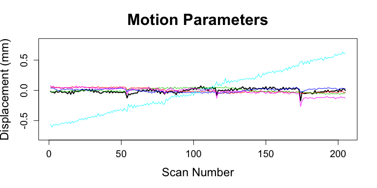

```r
mp = moco_params
mp[, 1:3] = mp[, 1:3] * 50
r = range(mp)
plot(mp[,1], type = "l", xlab = "Scan Number", main = "Motion Parameters",
     ylab = "Displacement (mm)",
     ylim = r * 1.25,
     lwd = 2,
     cex.main = 2,
     cex.lab = 1.5,
     cex.axis = 1.25)
for (i in 2:ncol(mp)) {
  lines(mp[, i], col = i)
}
```

```r
rm(list = "mp")
```